# Funnel L2S Model

Bernardo Lares

22/3/2017

## Modelo Lead To Sale (L2S)

En este documento resumiré los pasos seguidos para la generación del score generado con el **Funnel L2S Model** de X empresa, en el cual logramos calcular cuál es la probabilidad de que un lead o una oportunidad nueva vaya a convertir (comprar una póliza todo riesgo) y poder tomar mejores decisiones basadas en Machine Learning.

**NOTA**:Hay que tomar en cuenta que este score no varía con el tiempo ya que sólo tiene información referente a la persona como tal y no a su comportamiento.

El algorítmo definitivo empleado para generar los scores fue **XGBoost**, utilizando R (sampling, limpieza de data y modelo) y Python (implementación en el CRM).

## Sampling

Las librerías empleadas fueron las siguientes:

```r
library(RPostgreSQL)
library(dplyr)
library(stringr)
library(Amelia)
library(ggplot2)
library(gridExtra)
```

Luego, se trajo la data del servidor a R directamente usando **PostgreSQL** (se omite el código por motivos de seguridad). Las consultas realizadas de una tabla compuesta por las siguientes dos categorías:

```r
## EMITIDAS
q <- "
SELECT
DISTINCT(o.id),
random(),
o.created,
app.vehicle_body,
app.sex,
EXTRACT(year from app.date_of_birth) as year_of_birth,
app.vehicle_model,
app.vehicle_city,
app.current_situation,
app.vehicle_is_mine,
app.form,
app.already_insured_soat,
app.when_need_policy,
app.vehicle_financed,
app.vehicle_commercial_value,
app.identification,
app.vehicle_is_zero_km,
app.vehicle_has_registration,
app.client_type,
app.vehicle_service_type,
CASE WHEN app.already_insured_with_company IS NOT NULL THEN 'SI'
  ELSE 'NO' END as already_insured,
m.medium,
app.vehicle_brand,
o.quoted_policies_count

FROM applications_carinsuranceapplication as app
LEFT JOIN opportunities_opportunity as o ON (app.id = o.application_object_id)
LEFT JOIN opportunities_userjourney as uj ON (o.id = uj.opportunity_id)
LEFT JOIN opportunities_userjourneystepdone as sd ON (uj.id = sd.user_journey_id)
LEFT JOIN marketing_visitor as m ON (o.marketing_id = m.id)

WHERE
sd.name IN ('issue')
AND o.created BETWEEN '2016-01-01' AND (CURRENT_DATE - INTERVAL '1 month')
AND o.fake = FALSE
AND m.medium != 'api'
AND app.form NOT IN ('default','ux31')
AND o.status != 'descartada'
ORDER BY random()
LIMIT 10000"
q <- dbSendQuery(con, q)
emitidos <- fetch(q, n = -1)
emitidos$emitido <- c(1)
emitidos <- head(emitidos,6000) #Cuántos registros máximos queremos para "1s"

## NO EMITIDAS
q <- "
SELECT
DISTINCT(o.id),
random(),
o.created,
app.vehicle_body,
app.sex,
EXTRACT(year from app.date_of_birth) as year_of_birth,
app.vehicle_model,
app.vehicle_city,
app.current_situation,
app.vehicle_is_mine,
app.form,
app.already_insured_soat,
app.when_need_policy,
app.vehicle_financed,
app.vehicle_commercial_value,
app.identification,
app.vehicle_is_zero_km,
app.vehicle_has_registration,
app.client_type,
app.vehicle_service_type,
CASE WHEN app.already_insured_with_company IS NOT NULL THEN 'SI'
  ELSE 'NO' END as already_insured,
m.medium,
app.vehicle_brand,
o.quoted_policies_count

FROM applications_carinsuranceapplication as app
LEFT JOIN opportunities_opportunity as o ON (app.id = o.application_object_id)
LEFT JOIN opportunities_userjourney as uj ON (o.id = uj.opportunity_id)
LEFT JOIN opportunities_userjourneystepdone as sd ON (uj.id = sd.user_journey_id)
LEFT JOIN marketing_visitor as m ON (o.marketing_id = m.id)

WHERE
sd.name NOT IN ('issue','terms','payment','docs-physics','acquired','fin')
AND o.created BETWEEN '2016-01-01' AND (CURRENT_DATE - INTERVAL '1 month')
AND o.fake = FALSE
AND m.medium != 'api'
AND app.form NOT IN ('default','ux31')
AND o.status != 'descartada'
ORDER BY random()
LIMIT 8000"
q <- dbSendQuery(con, q)
no.emitidos <- fetch(q, n = -1)
no.emitidos <- filter(no.emitidos,!id %in% emitidos$id)
no.emitidos$emitido <- c(0)
no.emitidos <- head(no.emitidos,5000) #Cuántos registros máximos queremos para "0s"

## JOIN BOTH
sample <- rbind(emitidos,no.emitidos)
## Delete random()
sample$random <- NULL
#Reordenar
sample <- cbind(select(sample,emitido,id,created),select(sample,-emitido,-id,-created))

## EXPORT RAW
write.csv2(sample,"Data.16.raw.csv")
```

Ahora vemos la data que exportamos del servidor a un archivo CSV:

```r
str(sample)
```

```
## 'data.frame':    8545 obs. of  24 variables:
##  $ emitido                 : num  1 1 1 1 1 1 1 1 1 1 ...
##  $ id                      : int  409930 524091 433491 479206 415992 314664 437186 551997 552896 517335 ...
##  $ created                 : POSIXct, format: "2016-08-10 08:13:29" "2017-01-05 15:39:17" ...
##  $ vehicle_body            : chr  "AUTOMOVIL" "AUTOMOVIL" "AUTOMOVIL" "MOTOCICLETA" ...
##  $ sex                     : chr  "M" "M" "M" "M" ...
##  $ year_of_birth           : num  1976 1982 1969 1983 1986 ...
##  $ vehicle_model           : int  2013 2017 2008 2015 2007 2010 2013 2016 2016 2017 ...
##  $ vehicle_city            : chr  "Bogotá, Bogota D.C., Colombia" "Medellín, Antioquia, Colombia" "Bogotá, Bogota D.C., Colombia" "Cali, Valle del Cauca, Colombia" ...
##  $ current_situation       : chr  "" "" "" "" ...
##  $ vehicle_is_mine         : chr  "yes" NA "yes" "yes" ...
##  $ form                    : chr  "uj40" "uj40" "shorty" "shorty" ...
##  $ already_insured_soat    : chr  "only-have-soat" NA "only-have-soat" "only-have-soat" ...
##  $ when_need_policy        : chr  "inmediately" "inmediately" "inmediately" "inmediately" ...
##  $ vehicle_financed        : chr  NA "yes-bank-or-financial" NA NA ...
##  $ vehicle_commercial_value: num  33000000 65240000 19300000 4100000 10700000 ...
##  $ identification          : chr  "79840127" "98694582" "79635065" "94072489" ...
##  $ vehicle_is_zero_km      : int  0 1 0 0 0 0 0 0 0 1 ...
##  $ vehicle_has_registration: int  1 0 1 1 0 1 0 1 1 1 ...
##  $ client_type             : chr  "natural" "natural" "natural" "natural" ...
##  $ vehicle_service_type    : chr  "particular" "particular" "particular" "particular" ...
##  $ already_insured         : chr  "SI" "NO" "NO" "NO" ...
##  $ medium                  : chr  "ET" "cpc" "direct" "direct" ...
##  $ vehicle_brand           : chr  "VOLKSWAGEN" "KIA" "CHEVROLET" "SUZUKI" ...
##  $ quoted_policies_count   : int  10 9 10 1 13 16 1 13 10 12 ...
```

```r
head(sample,1)
```

```
##   emitido     id             created vehicle_body sex year_of_birth
## 1       1 409930 2016-08-10 08:13:29    AUTOMOVIL   M          1976
##   vehicle_model                  vehicle_city current_situation
## 1          2013 Bogotá, Bogota D.C., Colombia
##   vehicle_is_mine form already_insured_soat when_need_policy
## 1             yes uj40       only-have-soat      inmediately
##   vehicle_financed vehicle_commercial_value identification
## 1             <NA>                  3.3e+07       79840127
##   vehicle_is_zero_km vehicle_has_registration client_type
## 1                  0                        1     natural
##   vehicle_service_type already_insured medium vehicle_brand
## 1           particular              SI     ET    VOLKSWAGEN
##   quoted_policies_count
## 1                    10
```

```r
sample %>% group_by(emitido) %>% tally()
```

```
## # A tibble: 2 × 2
##   emitido     n
##     <dbl> <int>
## 1       0  5000
## 2       1  3545
```

## Limpieza y preparación de la data

Ahora que tenemos ya el extracto de la data que usaremos para el modelo, preparamos los campos que requieran organizar, limpiar, mejorar…

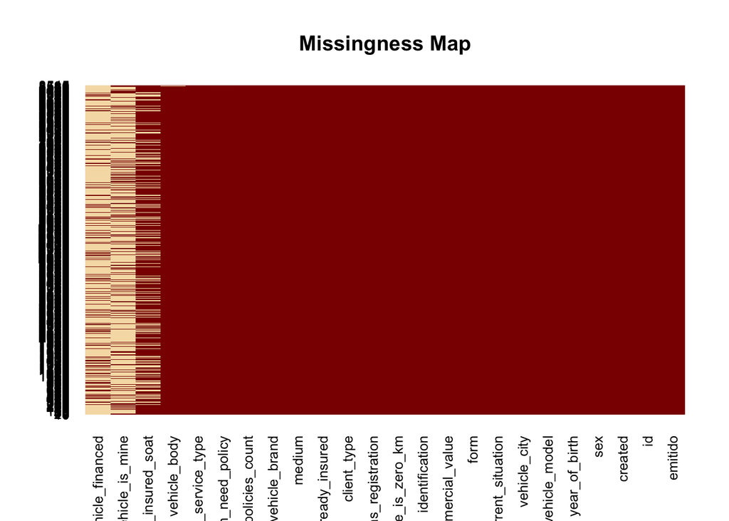

```r
df.train <- read.csv2('Data.16.raw.csv',stringsAsFactors=TRUE)
df.train$X <- NULL #No nos sirve
df.train$civil_status <- NULL #Mala data
df.train$email_address <- NULL #Mal predictor
df.train$domain <- NULL #Mal predictor
df.train$mobile_phone <- NULL #Mal predictor
df.train$phone <- NULL #Mal predictor

#Missing values
missmap(df.train,legend=FALSE,rank.order=TRUE)
```

```r
#CIUDADES
#Fix data
df.train$vehicle_city <- sub(", Colombia","",df.train$vehicle_city)
df.train$vehicle_city <- sub(", .*","",df.train$vehicle_city)
#View data - Ciudad
fix <- as.data.frame(df.train$vehicle_city)
fix <- fix %>% group_by(Campo=fix[,1]) %>% tally(sort = TRUE) %>%
  mutate(Perc=round(n/nrow(fix),2)) %>% top_n(10,n)
print(fix)
```

```
## # A tibble: 10 × 3
##           Campo     n  Perc
##          <fctr> <int> <dbl>
## 1        Bogotá  4193  0.49
## 2      Medellín  1711  0.20
## 3          Cali   933  0.11
## 4  Barranquilla   313  0.04
## 5   Bucaramanga   129  0.02
## 6       Pereira   117  0.01
## 7     Cartagena    97  0.01
## 8     Manizales    91  0.01
## 9        Ibagué    85  0.01
## 10      Armenia    52  0.01
```

```r
#Reescribir las campos por nueva agrupación
df.train <- df.train %>%
  mutate(vehicle_city = ifelse(vehicle_city=="Bogotá","BOG",
                               ifelse(vehicle_city=="Medellín","MED",
                                      ifelse(vehicle_city=="Cali","CAL",
                                             ifelse(vehicle_city=="Barranquilla","BAR","OTRA")))))

# NACIMIENTO - EDAD
df.train$year_of_birth[is.na(df.train$year_of_birth)] <- as.integer(format(Sys.time(), "%Y")) #NAs
df.train$edad <- as.integer(format(Sys.time(), "%Y")) - df.train$year_of_birth #Edades
df.train$year_of_birth <- NULL
df.train <- df.train %>%
  mutate(edad = ifelse(edad>=80,">80",
                       ifelse(edad>=55,"55-79",
                              ifelse(edad>=40,"40-54",
                                     ifelse(edad>=30,"30-39",
                                            ifelse(edad>=18,"18-29",
                                                   ifelse(edad>=1,"MENOR","SIN")))))))

# MODELO DEL VEHÍCULO
fix <- as.data.frame(df.train$vehicle_model)
fix <- fix %>% group_by(Campo=fix[,1]) %>% tally(sort = TRUE) %>%
  mutate(Perc=round(n/nrow(fix),2)) %>% top_n(10,n)
print(fix)
```

```
## # A tibble: 10 × 3
##    Campo     n  Perc
##    <int> <int> <dbl>
## 1   2016  1019  0.12
## 2   2015   976  0.11
## 3   2013   841  0.10
## 4   2012   829  0.10
## 5   2011   804  0.09
## 6   2017   794  0.09
## 7   2014   774  0.09
## 8   2008   460  0.05
## 9   2010   421  0.05
## 10  2009   419  0.05
```

```r
#Reescribir las campos por nueva agrupación
año <- as.integer(format(Sys.Date(), "%Y"))
df.train <- df.train %>%
  mutate(vehicle_model = ifelse(vehicle_model>=año,"DEL.AÑO",
                                ifelse(vehicle_model>=(año-1),"AÑO.PASADO",
                                       ifelse(vehicle_model>=(año-2),"AÑO.ANTEPASADO",
                                              ifelse(vehicle_model>=(año-5),"5.AÑOS",
                                                     ifelse(vehicle_model>=(año-10),"10.AÑOS","MAS.10.AÑOS"))))))

# MEDIUM
fix <- as.data.frame(df.train$medium)
fix <- fix %>% group_by(Campo=fix[,1]) %>% tally(sort = TRUE) %>%
  mutate(Perc=round(n/nrow(fix),2)) %>% top_n(10,n)
print(fix)
```

```
## # A tibble: 12 × 3
##                  Campo     n  Perc
##                 <fctr> <int> <dbl>
## 1                  cpc  3826  0.45
## 2               direct  1751  0.20
## 3                  seo  1719  0.20
## 4                   ET   837  0.10
## 5             referral   217  0.03
## 6     link-calculadora    85  0.01
## 7              autolab    15  0.00
## 8          EXACTTARGET    15  0.00
## 9              DISPLAY    10  0.00
## 10 facilidades de pago     9  0.00
## 11              widget     9  0.00
## 12                  WP     9  0.00
```

```r
#Reescribir las campos por nueva agrupación
df.train <- df.train %>%
  mutate(medium = ifelse(medium=="cpc","SEM",
                         ifelse(medium=="direct","DIRECT",
                                ifelse(medium=="seo","SEO",
                                       ifelse(medium=="et","ET",
                                              ifelse(medium=="referral","REFERRAL",
                                                     ifelse(medium=="INBOXLABS","INBOXLABS","OTRO")))))))

# BODY
fix <- as.data.frame(df.train$vehicle_body)
fix <- fix %>% group_by(Campo=fix[,1]) %>% tally(sort = TRUE) %>%
  mutate(Perc=round(n/nrow(fix),2)) %>% top_n(10,n)
print(fix)
```

```
## # A tibble: 10 × 3
##               Campo     n  Perc
##              <fctr> <int> <dbl>
## 1         AUTOMOVIL  5915  0.69
## 2         CAMIONETA  1465  0.17
## 3              MOTO   289  0.03
## 4  CAMIONETA PASAJ.   211  0.02
## 5           CAMPERO   211  0.02
## 6            PESADO   132  0.02
## 7            PICKUP   115  0.01
## 8  PICKUP DOBLE CAB    77  0.01
## 9       MOTOCICLETA    41  0.00
## 10              BUS    25  0.00
```

```r
#Reescribir las campos por nueva agrupación
df.train <- df.train %>%
  mutate(vehicle_body = ifelse(vehicle_body=="AUTOMOVIL","AUTOMOVIL",
                               ifelse(vehicle_body=="CAMIONETA","CAMIONETA",
                                      ifelse(vehicle_body=="MOTO","MOTO",
                                             ifelse(vehicle_body=="CAMPERO","CAMPERO",
                                                    ifelse(vehicle_body=="CAMIONETA PASAJ.","CAMIONETA PASAJ.",
                                                           ifelse(vehicle_body=="PICKUP","PICKUP","OTRO")))))))

# IDENTIFICACIÓN
fix <- as.data.frame(df.train$identification)
fix <- fix %>% group_by(Campo=fix[,1]) %>% tally(sort = TRUE) %>%
  mutate(Perc=round(n/nrow(fix),2)) %>% top_n(5,n)
print(fix)
```

```
## # A tibble: 24 × 3
##         Campo     n  Perc
##        <fctr> <int> <dbl>
## 1  0000000001  1443  0.17
## 2   000000001     5  0.00
## 3   900720376     5  0.00
## 4  1022407594     3  0.00
## 5  1024558143     3  0.00
## 6  1026132655     3  0.00
## 7  1036644733     3  0.00
## 8  1113619217     3  0.00
## 9    14997738     3  0.00
## 10   18514751     3  0.00
## # ... with 14 more rows
```

```r
#Reescribir las campos por nueva agrupación
df.train <- df.train %>% mutate(identification = ifelse(as.integer(identification)==1,0,1))
df.train$identification[is.na(df.train$identification)] <- 0

# CREATED (Día de semana)
df.train$weekday <- weekdays(as.Date(df.train$created,format='%Y-%m-%d',tz="BO"))

#Clases de los campos
for(i in c(1,1:ncol(df.train))) {
  df.train[,i] <- as.factor(df.train[,i])
}
df.train[,2] <- as.integer(as.character(df.train[,2]))

## EXPORT CLEAN
write.csv2(df.train,"Data.16.clean.csv")
str(df.train)
```

```
## 'data.frame':    8545 obs. of  25 variables:
##  $ emitido                 : Factor w/ 2 levels "0","1": 2 2 2 2 2 2 2 2 2 2 ...
##  $ id                      : int  409930 524091 433491 479206 415992 314664 437186 551997 552896 517335 ...
##  $ created                 : Factor w/ 8363 levels "2016-01-04 12:11:00",..: 1436 6426 2383 4229 1614 86 2555 7980 8054 6049 ...
##  $ vehicle_body            : Factor w/ 7 levels "AUTOMOVIL","CAMIONETA",..: 1 1 1 6 1 1 5 2 2 2 ...
##  $ sex                     : Factor w/ 3 levels "","F","M": 3 3 3 3 2 3 3 3 2 3 ...
##  $ vehicle_model           : Factor w/ 6 levels "10.AÑOS","5.AÑOS",..: 2 5 1 3 1 1 2 4 4 5 ...
##  $ vehicle_city            : Factor w/ 5 levels "BAR","BOG","CAL",..: 2 4 2 3 3 4 5 3 1 5 ...
##  $ current_situation       : Factor w/ 7 levels "","asociados",..: 1 1 1 1 1 5 1 1 1 1 ...
##  $ vehicle_is_mine         : Factor w/ 2 levels "no","yes": 2 NA 2 2 NA NA NA NA NA NA ...
##  $ form                    : Factor w/ 5 levels "rastreator-v2",..: 3 3 2 2 3 1 2 3 3 3 ...
##  $ already_insured_soat    : Factor w/ 4 levels "also-i-need-soat",..: 4 NA 4 4 1 NA 4 4 2 NA ...
##  $ when_need_policy        : Factor w/ 5 levels "asociados","between_one_and_two_weeks",..: 5 5 5 5 5 NA 4 5 5 5 ...
##  $ vehicle_financed        : Factor w/ 3 levels "no-use-savings",..: NA 2 NA NA NA NA NA NA NA 2 ...
##  $ vehicle_commercial_value: Factor w/ 1120 levels "410000","503000",..: 355 740 194 36 104 386 291 635 936 612 ...
##  $ identification          : Factor w/ 2 levels "0","1": 2 2 2 2 2 2 2 2 2 2 ...
##  $ vehicle_is_zero_km      : Factor w/ 2 levels "0","1": 1 2 1 1 1 1 1 1 1 2 ...
##  $ vehicle_has_registration: Factor w/ 2 levels "0","1": 2 1 2 2 1 2 1 2 2 2 ...
##  $ client_type             : Factor w/ 2 levels "juridica","natural": 2 2 2 2 2 2 2 2 2 2 ...
##  $ vehicle_service_type    : Factor w/ 4 levels "","particular",..: 2 2 2 2 2 2 2 2 2 2 ...
##  $ already_insured         : Factor w/ 2 levels "NO","SI": 2 1 1 1 1 1 1 1 1 1 ...
##  $ medium                  : Factor w/ 6 levels "DIRECT","INBOXLABS",..: 3 5 1 1 5 5 1 5 5 1 ...
##  $ vehicle_brand           : Factor w/ 82 levels "ACURA","AGRALE",..: 77 46 15 70 15 46 32 15 15 15 ...
##  $ quoted_policies_count   : Factor w/ 30 levels "0","1","2","3",..: 11 10 11 2 14 17 2 14 11 13 ...
##  $ edad                    : Factor w/ 5 levels "18-29","30-39",..: 3 2 3 2 2 2 3 4 1 2 ...
##  $ weekday                 : Factor w/ 7 levels "Friday","Monday",..: 7 5 3 5 7 3 5 6 7 7 ...
```

## Creación del Modelo

Una vez tenemos la data lista para nuestro modelo, podemos entrenarlo, ajustarlo y conseguir los mejores resultados.

Las librerías empleadas son las siguientes:

```r
library(dplyr)
library(xgboost)
library(data.table)
library(caTools)
library(pROC)
library(gridExtra)
library(caret)
library(ggplot2)
```

Importamos la data limpia para el modelo:

```r
df.train <- read.csv2('Data.16.clean.csv',stringsAsFactors=TRUE,na=as.factor("NULO"))
fechas <- paste(min(as.Date(df.train$created)),"-",max(as.Date(df.train$created)))
df.train$X <- NULL
df.train$vehicle_commercial_value <- as.numeric(as.character(df.train$vehicle_commercial_value))
df.train$vehicle_brand <- NULL #Noice
```

## Train y Test Data

```r
set.seed(1)
split <- sample.split(df.train$emitido, SplitRatio = 0.7)
train <- subset(df.train, split == TRUE) #Training
test <- subset(df.train, split == FALSE) #Testing

n <- nrow(test)
emitidos <- nrow(filter(test,emitido==1))
```

## One Hot Encoding para trabajar con XGBoost

Una vez tengamos nuestra data segmentada, la preparamos para XGBoost:

```r
setDT(train)
setDT(test)

#One hot encoding
labels <- train$emitido #Target train
ts_label <- test$emitido #Target test
new_tr <- model.matrix(~.+0,data = train[,-c("emitido","id","created"),with=F])
new_ts <- model.matrix(~.+0,data = test[,-c("emitido","id","created"),with=F])

#Convert data table into a matrix (xgb.DMatrix):
dtrain <- xgb.DMatrix(data = new_tr,label = labels)
dtest <- xgb.DMatrix(data = new_ts,label = ts_label)
```

## Parámetros iniciales para el modelo

Definimos los valores de los parámetros para iniciar el modelo:

```r
params <- list(
  booster = "gbtree", # 'gbtree' / 'gblinear'
  objective = "binary:logistic", # 'binary:logistic' / 'reg:linear'
  eta=0.1, #Step size shrinkage (prevents overfitting) - default=0.3
  gamma=0, #Minimum loss reduction required to split
  max_depth=5, #Default=6 <- Complexity (ver xgb.plot.deepness)
  min_child_weight=1,
  subsample=1,#Robust to noise
  colsample_bytree=1 #Robust to noise
)
```

Hacemos cross-validation buscando la mejor iteración para este modelo. Además, podemos calcular el Accuracy del cross-validation.

```r
xgbcv <- xgb.cv(params = params,
                data = dtrain,
                nrounds = 150, #n iteraciones
                nfold = 5, #folds cross validation
                showsd = T,
                stratified = T,
                print_every_n = 1, #Intervalos a mostrar
                early_stopping_rounds = 20, #20
                maximize = F,
                prediction = F)
```

[output not shown]

```r
#The model returned lowest error @:
bestn <- xgbcv$best_iteration #cambia cada vez = 68 empleado en CRM
paste("Mejor iteración:",bestn)
```

```
## [1] "Mejor iteración: 52"
```

```r
paste("CV Accuracy: ",round((1-min(xgbcv$evaluation_log$test_error_mean))*100,2),"%",sep="")
```

```
## [1] "CV Accuracy: 70.23%"
```

## Entrenamiento del modelo

Y ahora, entrenamos nuestro modelo de pruebas y calculamos Accuracy:

```r
xgb1 <- xgb.train(
  params = params,
  data = dtrain,
  nrounds = bestn, #default=bestn para no hacer overfitting
  watchlist = list(val=dtest,train=dtrain),
  print_every_n = 1,
  maximize = F,
  eval_metric = "error"
)
paste("Accuracy: ",round((1-min(xgb1$evaluation_log$val_error))*100,2),"%",sep="")
```

```
## [1] "Accuracy: 73%"
```

## Evaluación del modelo

Una vez satisfechos con el valor obtenido de Accuracy, podemos empezar a evaluar, predecir, estudiar los resultados y exportarlo.

```r
result <- as.data.frame(cbind(id_opp=train$id,date=as.Date(train$created),real=train$emitido,score=predict(xgb1,dtrain)))
result$date <- as.Date(result$date,origin='1970-01-01')
head(result)
```

```
##   id_opp       date real     score
## 1 409930 2016-08-10    1 0.5628895
## 2 524091 2017-01-05    1 0.2356761
## 3 433491 2016-09-10    1 0.7169653
## 4 415992 2016-08-17    1 0.2603933
## 5 551997 2017-02-14    1 0.5450000
## 6 552896 2017-02-15    1 0.3885509
```

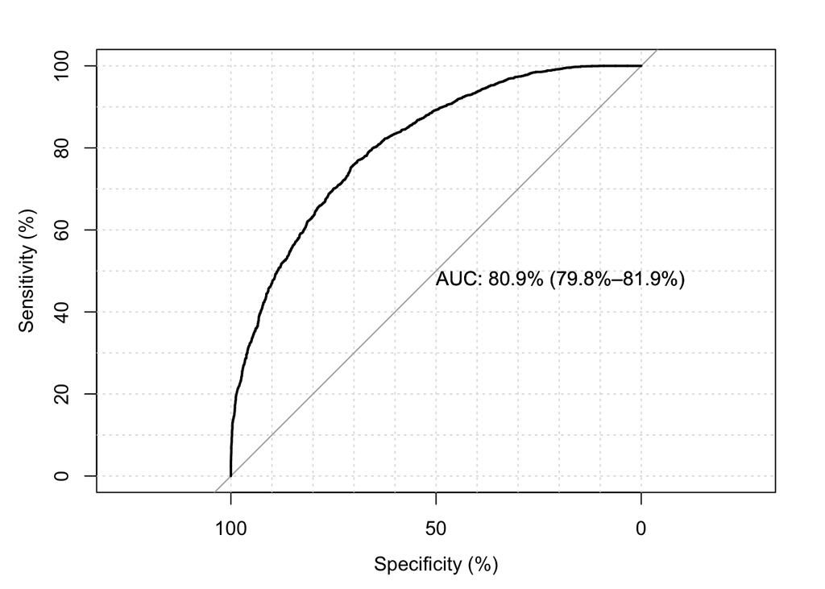

```r
threshold <- 0.3 #Definir threshold (0.5 es lo convencional pero depende del caso)
result <- result %>% mutate(predicción=ifelse(score>=threshold,1,0))
xgbpred <- predict(xgb1,dtest)
xgbpred <- ifelse(xgbpred>threshold,1,0)
mat <- xgb.importance(feature_names=colnames(new_tr),model=xgb1) # Importancia variables
MC <- table(test$emitido, xgbpred > threshold)
deciles <- quantile(result$score, probs = seq(0.1, 0.9, length = 9), names = TRUE)
deciles <- data.frame(cbind(
  Deciles=row.names(as.data.frame(deciles)),
  Threshold=as.data.frame(deciles)),row.names=NULL)
#Entonces, tenemos:
resultados <- list("Mejor iteración + ACC"=
                     paste(
                       max(xgb1$evaluation_log$iter),'<-',
                       round((1-min(xgb1$evaluation_log$val_error))*100,2),"%"),
                   "Top 10 predictores"=mat[1:10,1:2],
                   "Rango de fechas"=fechas,
                   "% Relación Emitidas"=paste(
                     round(emitidos/n,2),"<-",emitidos,"emitidos"),
                   "Matriz de Confusión @Threshold"=MC,
                   "Threshold empleada"=threshold,
                   "Accuracy (ACC) @Threshold"=round((MC[1,1]+MC[2,2])/n,4),
                   "% True Positives: emitida & gestionada"=MC[2,2]/emitidos,
                   "% True: total gestionadas"=(MC[1,2]+MC[2,2])/n,
                   "Curva ROC"=plot.roc(
                     x=result$real,
                     predictor=result$score,
                     smooth=FALSE,auc=TRUE,ci=TRUE,print.auc=TRUE,percent=TRUE,grid=TRUE),
                   "Deciles"=deciles)
```

```r
print(resultados)
```

```
## $`Mejor iteración + ACC`
## [1] "52 <- 73 %"
##
## $`Top 10 predictores`
##                                Feature       Gain
##  1:              quoted_policies_count 0.35040705
##  2:        when_need_policyinmediately 0.12192499
##  3:           vehicle_commercial_value 0.07523043
##  4:                           formuj40 0.06704095
##  5:           vehicle_has_registration 0.03987402
##  6:  when_need_policyin_a_week_or_less 0.03650641
##  7:                          mediumSEM 0.03408752
##  8:                         formshorty 0.02855945
##  9: when_need_policyin_a_month_or_more 0.02371690
## 10: already_insured_soatonly-have-soat 0.02210930
##
## $`Rango de fechas`
## [1] "2016-01-04 - 2017-02-22"
##
## $`% Relación Emitidas`
## [1] "0.41 <- 1063 emitidos"
##
## $`Matriz de Confusión @Threshold`
##
##     FALSE TRUE
##   0   624  876
##   1    95  968
##
## $`Threshold empleada`
## [1] 0.3
##
## $`Accuracy (ACC) @Threshold`
## [1] 0.6211
##
## $`% True Positives: emitida & gestionada`
## [1] 0.9106303
##
## $`% True: total gestionadas`
## [1] 0.7194694
##
## $`Curva ROC`
##
## Call:
## plot.roc.default(x = result$real, predictor = result$score, smooth = FALSE,     auc = TRUE, ci = TRUE, print.auc = TRUE, percent = TRUE,     grid = TRUE)
##
## Data: result$score in 3500 controls (result$real 0) < 2482 cases (result$real 1).
## Area under the curve: 80.87%
## 95% CI: 79.8%-81.95% (DeLong)
##
## $Deciles
##   Deciles   deciles
## 1     10% 0.1566591
## 2     20% 0.2528037
## 3     30% 0.3112978
## 4     40% 0.3594880
## 5     50% 0.4017697
## 6     60% 0.4435182
## 7     70% 0.5036746
## 8     80% 0.5870904
## 9     90% 0.6987775
```

## Gráficas para visualizar los resultados

Veamos algunos gráficos:

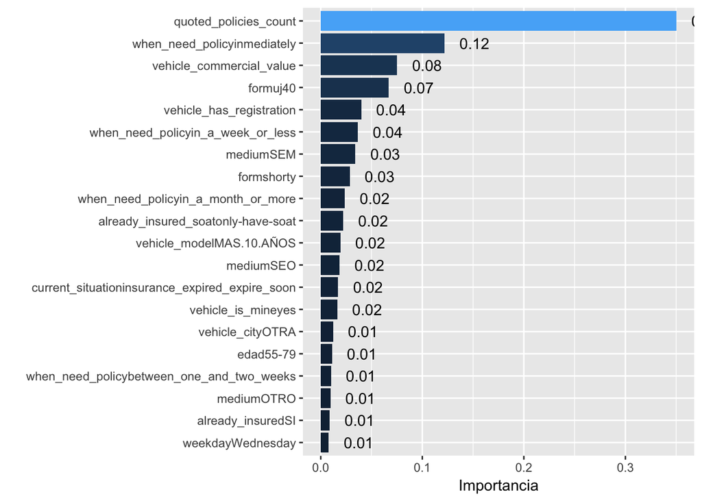

```r
grid.arrange(arrangeGrob(
  ggplot(mat[1:20,1:2],
         aes(x=reorder(Feature,Gain),
             y=Gain,
             label=round(Gain,2),fill=as.numeric(Gain))) +
    geom_col() + coord_flip() + xlab('') + ylab('Importancia') +
    guides(fill=FALSE) + geom_text(hjust=-0.5)))
```

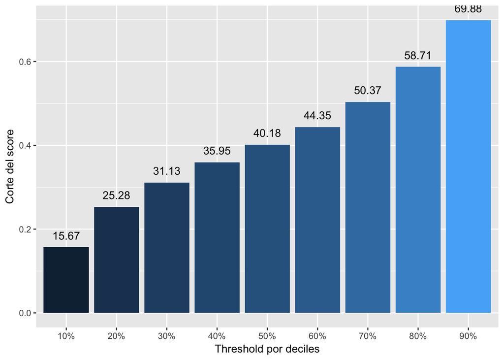

```r
ggplot(deciles, aes(
  x=Deciles,
  y=deciles,
  label=round(deciles*100,2),fill=as.numeric(deciles))) +
  geom_col() +
  xlab('Threshold por deciles') + ylab('Corte del score') +
  guides(fill=FALSE) + geom_text(vjust=-1)
```

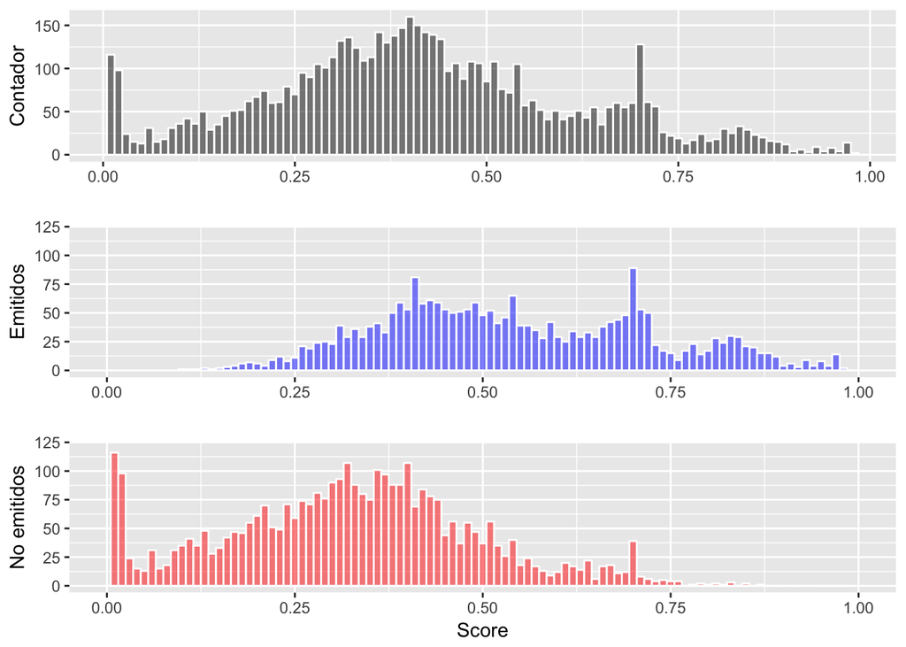

```r
grid.arrange(ggplot(as.data.frame(result))+
               geom_histogram(
                 aes(x=score),
                 binwidth = 0.01, fill="black", color="white", alpha=0.5) +
               ylab("Contador") + xlab(''),
             ggplot(filter(result,real==1)) +
               geom_histogram(
                 aes(x=score),
                 binwidth = 0.01, fill="blue", color="white", alpha=0.5) +
               xlab('') + ylab('Emitidos') +
               xlim(0, 1) + ylim(0,120),
             ggplot(filter(result,real==0)) +
               geom_histogram(
                 aes(x=score),
                 binwidth = 0.01, fill="red", color="white", alpha=0.5) +
               xlab('Score') + ylab('No emitidos') +
               xlim(0, 1) + ylim(0,120), ncol=1)
```

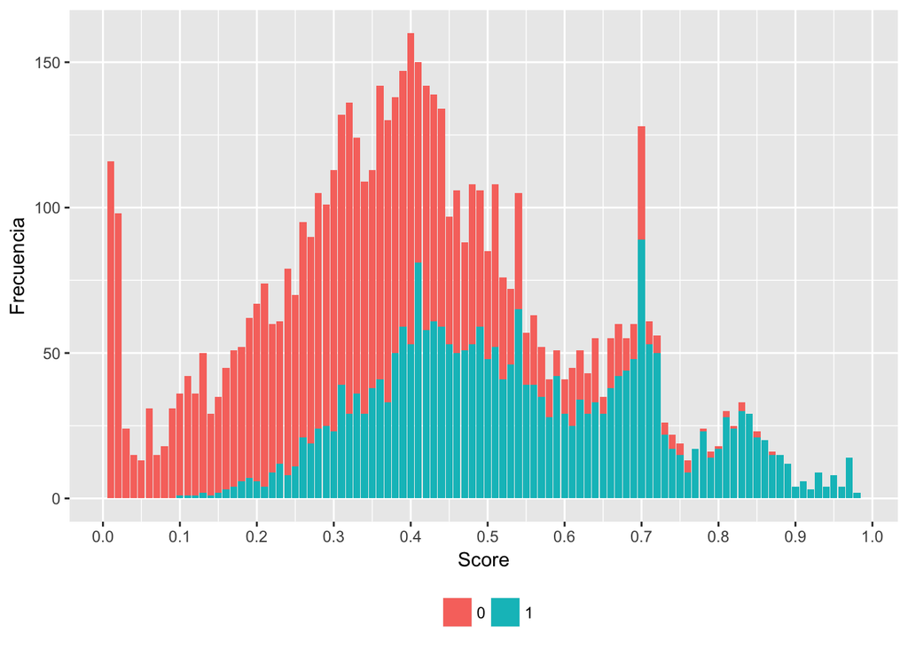

```r
ggplot(select(result,real,round(score,2)) %>%
         group_by(Score=round(score,2),Emisión=real) %>% tally()) +
  geom_bar(
    aes(x=Score,y=n,fill = as.factor(Emisión)),stat="identity") +
  ylab('Frecuencia') +
  scale_x_continuous(breaks = round(seq(0, 1, by = 0.1),1)) +
  theme(legend.position="bottom", legend.direction="horizontal", legend.title = element_blank())
```

```r
xgbi <- xgb.train(params = params,data = dtrain,
  nrounds = 200, #default=bestn para no hacer overfitting
  watchlist = list(val=dtest,train=dtrain),print_every_n = 1,maximize = F,eval_metric = "error")
```

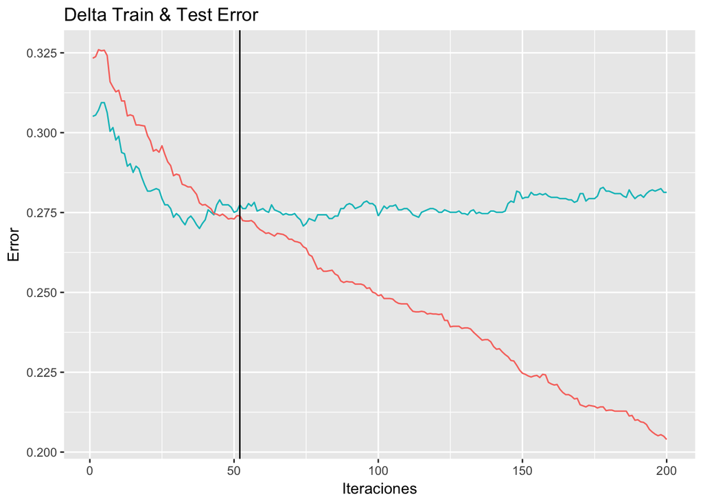

```r
val_error <- as.data.frame(xgbi$evaluation_log$val_error)
train_error <- as.data.frame(xgbi$evaluation_log$train_error)
ggplot(val_error, aes(row(val_error))) +
  geom_line(aes(y = abs(val_error),color='red')) +
  geom_line(aes(y = abs(train_error),color='blue')) +
  xlab('Iteraciones') + ylab('Error') +
  ggtitle('Delta Train & Test Error') + guides(colour=FALSE) +
  geom_vline(xintercept=bestn)  #bestn used in model
```

## Exportación del modelo

Exportemos ahora nuestro modelo en formato binario para luego ser implementado en nuestro CRM usando Python y XGBoost.

```r
xgb.save(xgb1, fname="xgb1.model")
```

```
## [1] TRUE
```

```r
# Chequeo si se exportó bien:
pred <- predict(xgb1,dtrain)
# Cargamos el modelo binario
xgb2 <- xgb.load("xgb1.model")
pred2 <- predict(xgb2, dtrain, ntreelimit = bestn)
# pred2 = pred ? Perfecto:
sum(abs(pred2-pred))
```

```
## [1] 0
```